# Risk Factor Analysis

## Outcome Variable

**Outcome Variable:** wast_rec90d

## Predictor Variables

**Intervention Variable:** birthwt

**Adjustment Set:**

- arm
- sex
- W_mage
- meducyrs
- feducyrs
- vagbrth
- single
- brthmon
- W_parity
- delta_W_mage
- delta_meducyrs
- delta_feducyrs
- delta_vagbrth
- delta_single
- delta_brthmon
- delta_W_parity

## Stratifying Variables

The analysis was stratified on these variable(s):

- agecat
- studyid
- country

## Data Summary

| agecat | studyid | country | birthwt | wast_rec90d | n_cell | n |
| --- | --- | --- | --- | --- | --- | --- |
| 0-24 months | ki0047075b-MAL-ED | BANGLADESH | Normal or high birthweight | 0 | 31 | 122 |
| 0-24 months | ki0047075b-MAL-ED | BANGLADESH | Normal or high birthweight | 1 | 46 | 122 |
| 0-24 months | ki0047075b-MAL-ED | BANGLADESH | Low birthweight | 0 | 12 | 122 |
| 0-24 months | ki0047075b-MAL-ED | BANGLADESH | Low birthweight | 1 | 33 | 122 |
| 0-24 months | ki0047075b-MAL-ED | BRAZIL | Normal or high birthweight | 0 | 5 | 24 |
| 0-24 months | ki0047075b-MAL-ED | BRAZIL | Normal or high birthweight | 1 | 16 | 24 |
| 0-24 months | ki0047075b-MAL-ED | BRAZIL | Low birthweight | 0 | 1 | 24 |
| 0-24 months | ki0047075b-MAL-ED | BRAZIL | Low birthweight | 1 | 2 | 24 |
| 0-24 months | ki0047075b-MAL-ED | INDIA | Normal or high birthweight | 0 | 44 | 166 |
| 0-24 months | ki0047075b-MAL-ED | INDIA | Normal or high birthweight | 1 | 78 | 166 |
| 0-24 months | ki0047075b-MAL-ED | INDIA | Low birthweight | 0 | 20 | 166 |
| 0-24 months | ki0047075b-MAL-ED | INDIA | Low birthweight | 1 | 24 | 166 |
| 0-24 months | ki0047075b-MAL-ED | NEPAL | Normal or high birthweight | 0 | 13 | 90 |
| 0-24 months | ki0047075b-MAL-ED | NEPAL | Normal or high birthweight | 1 | 60 | 90 |
| 0-24 months | ki0047075b-MAL-ED | NEPAL | Low birthweight | 0 | 3 | 90 |
| 0-24 months | ki0047075b-MAL-ED | NEPAL | Low birthweight | 1 | 14 | 90 |
| 0-24 months | ki0047075b-MAL-ED | PERU | Normal or high birthweight | 0 | 3 | 35 |
| 0-24 months | ki0047075b-MAL-ED | PERU | Normal or high birthweight | 1 | 23 | 35 |
| 0-24 months | ki0047075b-MAL-ED | PERU | Low birthweight | 0 | 3 | 35 |
| 0-24 months | ki0047075b-MAL-ED | PERU | Low birthweight | 1 | 6 | 35 |
| 0-24 months | ki0047075b-MAL-ED | SOUTH AFRICA | Normal or high birthweight | 0 | 17 | 85 |
| 0-24 months | ki0047075b-MAL-ED | SOUTH AFRICA | Normal or high birthweight | 1 | 54 | 85 |
| 0-24 months | ki0047075b-MAL-ED | SOUTH AFRICA | Low birthweight | 0 | 1 | 85 |
| 0-24 months | ki0047075b-MAL-ED | SOUTH AFRICA | Low birthweight | 1 | 13 | 85 |
| 0-24 months | ki0047075b-MAL-ED | TANZANIA, UNITED REPUBLIC OF | Normal or high birthweight | 0 | 6 | 39 |
| 0-24 months | ki0047075b-MAL-ED | TANZANIA, UNITED REPUBLIC OF | Normal or high birthweight | 1 | 31 | 39 |
| 0-24 months | ki0047075b-MAL-ED | TANZANIA, UNITED REPUBLIC OF | Low birthweight | 0 | 0 | 39 |
| 0-24 months | ki0047075b-MAL-ED | TANZANIA, UNITED REPUBLIC OF | Low birthweight | 1 | 2 | 39 |
| 0-24 months | ki1000108-CMC-V-BCS-2002 | INDIA | Normal or high birthweight | 0 | 97 | 324 |
| 0-24 months | ki1000108-CMC-V-BCS-2002 | INDIA | Normal or high birthweight | 1 | 173 | 324 |

[output cut: 282 more lines]

The following strata were considered:

- agecat: 0-24 months, studyid: ki0047075b-MAL-ED, country: BANGLADESH
- agecat: 0-24 months, studyid: ki0047075b-MAL-ED, country: BRAZIL
- agecat: 0-24 months, studyid: ki0047075b-MAL-ED, country: INDIA
- agecat: 0-24 months, studyid: ki0047075b-MAL-ED, country: NEPAL
- agecat: 0-24 months, studyid: ki0047075b-MAL-ED, country: PERU
- agecat: 0-24 months, studyid: ki0047075b-MAL-ED, country: SOUTH AFRICA
- agecat: 0-24 months, studyid: ki0047075b-MAL-ED, country: TANZANIA, UNITED REPUBLIC OF
- agecat: 0-24 months, studyid: ki1000108-CMC-V-BCS-2002, country: INDIA
- agecat: 0-24 months, studyid: ki1000108-IRC, country: INDIA
- agecat: 0-24 months, studyid: ki1000109-EE, country: PAKISTAN
- agecat: 0-24 months, studyid: ki1000109-ResPak, country: PAKISTAN
- agecat: 0-24 months, studyid: ki1000304b-SAS-CompFeed, country: INDIA
- agecat: 0-24 months, studyid: ki1017093-NIH-Birth, country: BANGLADESH
- agecat: 0-24 months, studyid: ki1017093b-PROVIDE, country: BANGLADESH
- agecat: 0-24 months, studyid: ki1017093c-NIH-Crypto, country: BANGLADESH
- agecat: 0-24 months, studyid: ki1066203-TanzaniaChild2, country: TANZANIA, UNITED REPUBLIC OF
- agecat: 0-24 months, studyid: ki1101329-Keneba, country: GAMBIA
- agecat: 0-24 months, studyid: ki1113344-GMS-Nepal, country: NEPAL
- agecat: 0-24 months, studyid: ki1114097-CMIN, country: BANGLADESH
- agecat: 0-24 months, studyid: ki1119695-PROBIT, country: BELARUS
- agecat: 0-24 months, studyid: ki1126311-ZVITAMBO, country: ZIMBABWE
- agecat: 0-24 months, studyid: ki1135781-COHORTS, country: GUATEMALA
- agecat: 0-24 months, studyid: ki1135781-COHORTS, country: INDIA
- agecat: 0-24 months, studyid: ki1135781-COHORTS, country: PHILIPPINES
- agecat: 0-24 months, studyid: kiGH5241-JiVitA-3, country: BANGLADESH
- agecat: 0-24 months, studyid: kiGH5241-JiVitA-4, country: BANGLADESH
- agecat: 0-6 months, studyid: ki0047075b-MAL-ED, country: BANGLADESH
- agecat: 0-6 months, studyid: ki0047075b-MAL-ED, country: BRAZIL
- agecat: 0-6 months, studyid: ki0047075b-MAL-ED, country: INDIA
- agecat: 0-6 months, studyid: ki0047075b-MAL-ED, country: NEPAL
- agecat: 0-6 months, studyid: ki0047075b-MAL-ED, country: PERU
- agecat: 0-6 months, studyid: ki0047075b-MAL-ED, country: SOUTH AFRICA
- agecat: 0-6 months, studyid: ki0047075b-MAL-ED, country: TANZANIA, UNITED REPUBLIC OF
- agecat: 0-6 months, studyid: ki1000108-CMC-V-BCS-2002, country: INDIA
- agecat: 0-6 months, studyid: ki1000108-IRC, country: INDIA
- agecat: 0-6 months, studyid: ki1000109-EE, country: PAKISTAN
- agecat: 0-6 months, studyid: ki1000109-ResPak, country: PAKISTAN
- agecat: 0-6 months, studyid: ki1000304b-SAS-CompFeed, country: INDIA
- agecat: 0-6 months, studyid: ki1017093-NIH-Birth, country: BANGLADESH
- agecat: 0-6 months, studyid: ki1017093b-PROVIDE, country: BANGLADESH
- agecat: 0-6 months, studyid: ki1017093c-NIH-Crypto, country: BANGLADESH
- agecat: 0-6 months, studyid: ki1066203-TanzaniaChild2, country: TANZANIA, UNITED REPUBLIC OF
- agecat: 0-6 months, studyid: ki1101329-Keneba, country: GAMBIA
- agecat: 0-6 months, studyid: ki1113344-GMS-Nepal, country: NEPAL
- agecat: 0-6 months, studyid: ki1114097-CMIN, country: BANGLADESH
- agecat: 0-6 months, studyid: ki1119695-PROBIT, country: BELARUS
- agecat: 0-6 months, studyid: ki1126311-ZVITAMBO, country: ZIMBABWE
- agecat: 0-6 months, studyid: ki1135781-COHORTS, country: GUATEMALA
- agecat: 0-6 months, studyid: ki1135781-COHORTS, country: INDIA
- agecat: 0-6 months, studyid: ki1135781-COHORTS, country: PHILIPPINES
- agecat: 0-6 months, studyid: kiGH5241-JiVitA-3, country: BANGLADESH
- agecat: 0-6 months, studyid: kiGH5241-JiVitA-4, country: BANGLADESH
- agecat: 6-24 months, studyid: ki0047075b-MAL-ED, country: BANGLADESH
- agecat: 6-24 months, studyid: ki0047075b-MAL-ED, country: BRAZIL
- agecat: 6-24 months, studyid: ki0047075b-MAL-ED, country: INDIA
- agecat: 6-24 months, studyid: ki0047075b-MAL-ED, country: NEPAL
- agecat: 6-24 months, studyid: ki0047075b-MAL-ED, country: PERU
- agecat: 6-24 months, studyid: ki0047075b-MAL-ED, country: SOUTH AFRICA
- agecat: 6-24 months, studyid: ki0047075b-MAL-ED, country: TANZANIA, UNITED REPUBLIC OF
- agecat: 6-24 months, studyid: ki1000108-CMC-V-BCS-2002, country: INDIA
- agecat: 6-24 months, studyid: ki1000108-IRC, country: INDIA
- agecat: 6-24 months, studyid: ki1000109-EE, country: PAKISTAN
- agecat: 6-24 months, studyid: ki1000109-ResPak, country: PAKISTAN
- agecat: 6-24 months, studyid: ki1000304b-SAS-CompFeed, country: INDIA
- agecat: 6-24 months, studyid: ki1017093-NIH-Birth, country: BANGLADESH
- agecat: 6-24 months, studyid: ki1017093b-PROVIDE, country: BANGLADESH
- agecat: 6-24 months, studyid: ki1017093c-NIH-Crypto, country: BANGLADESH
- agecat: 6-24 months, studyid: ki1066203-TanzaniaChild2, country: TANZANIA, UNITED REPUBLIC OF
- agecat: 6-24 months, studyid: ki1101329-Keneba, country: GAMBIA
- agecat: 6-24 months, studyid: ki1113344-GMS-Nepal, country: NEPAL
- agecat: 6-24 months, studyid: ki1114097-CMIN, country: BANGLADESH
- agecat: 6-24 months, studyid: ki1119695-PROBIT, country: BELARUS
- agecat: 6-24 months, studyid: ki1126311-ZVITAMBO, country: ZIMBABWE
- agecat: 6-24 months, studyid: ki1135781-COHORTS, country: GUATEMALA
- agecat: 6-24 months, studyid: ki1135781-COHORTS, country: INDIA
- agecat: 6-24 months, studyid: ki1135781-COHORTS, country: PHILIPPINES
- agecat: 6-24 months, studyid: kiGH5241-JiVitA-3, country: BANGLADESH
- agecat: 6-24 months, studyid: kiGH5241-JiVitA-4, country: BANGLADESH

### Dropped Strata

Some strata were dropped due to rare outcomes:

- agecat: 0-24 months, studyid: ki0047075b-MAL-ED, country: BRAZIL
- agecat: 0-24 months, studyid: ki0047075b-MAL-ED, country: NEPAL
- agecat: 0-24 months, studyid: ki0047075b-MAL-ED, country: PERU
- agecat: 0-24 months, studyid: ki0047075b-MAL-ED, country: SOUTH AFRICA
- agecat: 0-24 months, studyid: ki0047075b-MAL-ED, country: TANZANIA, UNITED REPUBLIC OF
- agecat: 0-24 months, studyid: ki1000109-ResPak, country: PAKISTAN
- agecat: 0-24 months, studyid: ki1114097-CMIN, country: BANGLADESH
- agecat: 0-24 months, studyid: ki1119695-PROBIT, country: BELARUS
- agecat: 0-6 months, studyid: ki0047075b-MAL-ED, country: BANGLADESH
- agecat: 0-6 months, studyid: ki0047075b-MAL-ED, country: BRAZIL
- agecat: 0-6 months, studyid: ki0047075b-MAL-ED, country: NEPAL
- agecat: 0-6 months, studyid: ki0047075b-MAL-ED, country: PERU
- agecat: 0-6 months, studyid: ki0047075b-MAL-ED, country: SOUTH AFRICA
- agecat: 0-6 months, studyid: ki0047075b-MAL-ED, country: TANZANIA, UNITED REPUBLIC OF
- agecat: 0-6 months, studyid: ki1000109-ResPak, country: PAKISTAN
- agecat: 0-6 months, studyid: ki1114097-CMIN, country: BANGLADESH
- agecat: 0-6 months, studyid: ki1119695-PROBIT, country: BELARUS
- agecat: 6-24 months, studyid: ki0047075b-MAL-ED, country: BRAZIL
- agecat: 6-24 months, studyid: ki0047075b-MAL-ED, country: NEPAL
- agecat: 6-24 months, studyid: ki0047075b-MAL-ED, country: PERU
- agecat: 6-24 months, studyid: ki0047075b-MAL-ED, country: SOUTH AFRICA
- agecat: 6-24 months, studyid: ki0047075b-MAL-ED, country: TANZANIA, UNITED REPUBLIC OF
- agecat: 6-24 months, studyid: ki1000109-ResPak, country: PAKISTAN
- agecat: 6-24 months, studyid: ki1017093c-NIH-Crypto, country: BANGLADESH
- agecat: 6-24 months, studyid: ki1114097-CMIN, country: BANGLADESH
- agecat: 6-24 months, studyid: ki1119695-PROBIT, country: BELARUS
- agecat: 6-24 months, studyid: ki1135781-COHORTS, country: GUATEMALA
- agecat: 6-24 months, studyid: ki1135781-COHORTS, country: INDIA
- agecat: 6-24 months, studyid: kiGH5241-JiVitA-3, country: BANGLADESH

## Methods Detail

We’re interested in the causal parameters $E[Y_a]$ for all values of $a \in \mathcal{A}$. These parameters represent the mean outcome if, possibly contrary to fact, we intervened to set all units to have $A=a$. Under the randomization and positivity assumptions, these are identified by the statistical parameters $\psi_a=E_W[E_{Y|A,W}(Y|A=a,W)]$. In addition, we’re interested in the mean of $Y$, $E[Y]$ under no intervention (the observed mean). We will estimate these parameters by using SuperLearner to fit the relevant likelihood factors – $E_{Y|A,W}(Y|A=a,W)$ and $p(A=a|W)$, and then updating our likelihood fit using a joint TMLE.

For unadjusted analyses ($W=\{\}$), initial likelihoods were estimated using Lrnr_glm to estimate the simple $E(Y|A)$ and Lrnr_mean to estimate $p(A)$. For adjusted analyses, a small library containing Lrnr_glmnet, Lrnr_xgboost, and Lrnr_mean was used.

Having estimated these parameters, we will then use the delta method to estimate relative risks and attributable risks relative to a prespecified baseline level of $A$.

# Results Detail

## Results Plots

[figure not shown]

[figure not shown]

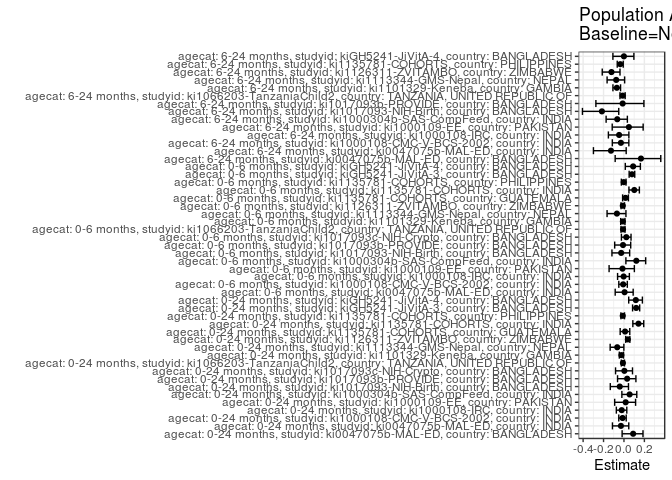

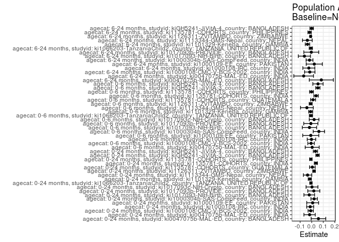

## Results Table

### Parameter: TSM

| agecat | studyid | country | intervention_level | baseline_level | estimate | ci_lower | ci_upper |
| --- | --- | --- | --- | --- | --- | --- | --- |
| 0-24 months | ki0047075b-MAL-ED | BANGLADESH | Normal or high birthweight | NA | 0.5892990 | 0.4680116 | 0.7105864 |
| 0-24 months | ki0047075b-MAL-ED | BANGLADESH | Low birthweight | NA | 0.7067388 | 0.5951237 | 0.8183539 |
| 0-24 months | ki0047075b-MAL-ED | INDIA | Normal or high birthweight | NA | 0.6327384 | 0.5349136 | 0.7305632 |
| 0-24 months | ki0047075b-MAL-ED | INDIA | Low birthweight | NA | 0.4948959 | 0.3434846 | 0.6463072 |
| 0-24 months | ki1000108-CMC-V-BCS-2002 | INDIA | Normal or high birthweight | NA | 0.6382790 | 0.5755683 | 0.7009897 |
| 0-24 months | ki1000108-CMC-V-BCS-2002 | INDIA | Low birthweight | NA | 0.5525154 | 0.4316896 | 0.6733413 |
| 0-24 months | ki1000108-IRC | INDIA | Normal or high birthweight | NA | 0.6028425 | 0.5406937 | 0.6649913 |
| 0-24 months | ki1000108-IRC | INDIA | Low birthweight | NA | 0.5472766 | 0.4485248 | 0.6460284 |
| 0-24 months | ki1000109-EE | PAKISTAN | Normal or high birthweight | NA | 0.4946206 | 0.4129737 | 0.5762676 |
| 0-24 months | ki1000109-EE | PAKISTAN | Low birthweight | NA | 0.5043620 | 0.4150601 | 0.5936639 |
| 0-24 months | ki1000304b-SAS-CompFeed | INDIA | Normal or high birthweight | NA | 0.3610932 | 0.3146302 | 0.4075563 |
| 0-24 months | ki1000304b-SAS-CompFeed | INDIA | Low birthweight | NA | 0.4150308 | 0.3616581 | 0.4684036 |
| 0-24 months | ki1017093-NIH-Birth | BANGLADESH | Normal or high birthweight | NA | 0.5383631 | 0.4653293 | 0.6113969 |
| 0-24 months | ki1017093-NIH-Birth | BANGLADESH | Low birthweight | NA | 0.4910656 | 0.4186791 | 0.5634520 |
| 0-24 months | ki1017093b-PROVIDE | BANGLADESH | Normal or high birthweight | NA | 0.5629831 | 0.4827006 | 0.6432656 |
| 0-24 months | ki1017093b-PROVIDE | BANGLADESH | Low birthweight | NA | 0.6094948 | 0.5296726 | 0.6893169 |
| 0-24 months | ki1017093c-NIH-Crypto | BANGLADESH | Normal or high birthweight | NA | 0.6200280 | 0.5380694 | 0.7019866 |
| 0-24 months | ki1017093c-NIH-Crypto | BANGLADESH | Low birthweight | NA | 0.6143617 | 0.5444024 | 0.6843209 |
| 0-24 months | ki1066203-TanzaniaChild2 | TANZANIA, UNITED REPUBLIC OF | Normal or high birthweight | NA | 0.6322894 | 0.5932904 | 0.6712883 |
| 0-24 months | ki1066203-TanzaniaChild2 | TANZANIA, UNITED REPUBLIC OF | Low birthweight | NA | 0.5465125 | 0.3591280 | 0.7338970 |
| 0-24 months | ki1101329-Keneba | GAMBIA | Normal or high birthweight | NA | 0.6770702 | 0.6453580 | 0.7087823 |
| 0-24 months | ki1101329-Keneba | GAMBIA | Low birthweight | NA | 0.5968197 | 0.5386432 | 0.6549961 |
| 0-24 months | ki1113344-GMS-Nepal | NEPAL | Normal or high birthweight | NA | 0.5770287 | 0.5212938 | 0.6327636 |
| 0-24 months | ki1113344-GMS-Nepal | NEPAL | Low birthweight | NA | 0.4954205 | 0.4284600 | 0.5623811 |
| 0-24 months | ki1126311-ZVITAMBO | ZIMBABWE | Normal or high birthweight | NA | 0.5237681 | 0.5036989 | 0.5438372 |
| 0-24 months | ki1126311-ZVITAMBO | ZIMBABWE | Low birthweight | NA | 0.5897860 | 0.5614959 | 0.6180762 |
| 0-24 months | ki1135781-COHORTS | GUATEMALA | Normal or high birthweight | NA | 0.5099504 | 0.4493869 | 0.5705140 |
| 0-24 months | ki1135781-COHORTS | GUATEMALA | Low birthweight | NA | 0.5425571 | 0.3873193 | 0.6977950 |
| 0-24 months | ki1135781-COHORTS | INDIA | Normal or high birthweight | NA | 0.2196216 | 0.1985994 | 0.2406437 |
| 0-24 months | ki1135781-COHORTS | INDIA | Low birthweight | NA | 0.3160961 | 0.2869677 | 0.3452244 |

[output cut: 68 more lines]

### Parameter: E(Y)

| agecat | studyid | country | intervention_level | baseline_level | estimate | ci_lower | ci_upper |
| --- | --- | --- | --- | --- | --- | --- | --- |
| 0-24 months | ki0047075b-MAL-ED | BANGLADESH | NA | NA | 0.6475410 | 0.5607680 | 0.7343140 |
| 0-24 months | ki0047075b-MAL-ED | INDIA | NA | NA | 0.6144578 | 0.5320591 | 0.6968566 |
| 0-24 months | ki1000108-CMC-V-BCS-2002 | INDIA | NA | NA | 0.6296296 | 0.5734927 | 0.6857666 |
| 0-24 months | ki1000108-IRC | INDIA | NA | NA | 0.5897436 | 0.5370721 | 0.6424150 |
| 0-24 months | ki1000109-EE | PAKISTAN | NA | NA | 0.5031056 | 0.4439609 | 0.5622503 |
| 0-24 months | ki1000304b-SAS-CompFeed | INDIA | NA | NA | 0.3822441 | 0.3470621 | 0.4174262 |
| 0-24 months | ki1017093-NIH-Birth | BANGLADESH | NA | NA | 0.5171569 | 0.4657250 | 0.5685888 |
| 0-24 months | ki1017093b-PROVIDE | BANGLADESH | NA | NA | 0.5811688 | 0.5245443 | 0.6377934 |
| 0-24 months | ki1017093c-NIH-Crypto | BANGLADESH | NA | NA | 0.6225806 | 0.5684562 | 0.6767051 |
| 0-24 months | ki1066203-TanzaniaChild2 | TANZANIA, UNITED REPUBLIC OF | NA | NA | 0.6258890 | 0.5879514 | 0.6638267 |
| 0-24 months | ki1101329-Keneba | GAMBIA | NA | NA | 0.6606557 | 0.6326585 | 0.6886530 |
| 0-24 months | ki1113344-GMS-Nepal | NEPAL | NA | NA | 0.5413417 | 0.4990070 | 0.5836763 |
| 0-24 months | ki1126311-ZVITAMBO | ZIMBABWE | NA | NA | 0.5443459 | 0.5279394 | 0.5607524 |
| 0-24 months | ki1135781-COHORTS | GUATEMALA | NA | NA | 0.5156250 | 0.4594779 | 0.5717721 |
| 0-24 months | ki1135781-COHORTS | INDIA | NA | NA | 0.2559618 | 0.2388022 | 0.2731215 |
| 0-24 months | ki1135781-COHORTS | PHILIPPINES | NA | NA | 0.6069712 | 0.5823178 | 0.6316245 |
| 0-24 months | kiGH5241-JiVitA-3 | BANGLADESH | NA | NA | 0.4230769 | 0.4110235 | 0.4351303 |
| 0-24 months | kiGH5241-JiVitA-4 | BANGLADESH | NA | NA | 0.2783678 | 0.2569102 | 0.2998254 |
| 0-6 months | ki0047075b-MAL-ED | INDIA | NA | NA | 0.6875000 | 0.5835705 | 0.7914295 |
| 0-6 months | ki1000108-CMC-V-BCS-2002 | INDIA | NA | NA | 0.6716418 | 0.6057305 | 0.7375531 |
| 0-6 months | ki1000108-IRC | INDIA | NA | NA | 0.6355932 | 0.5725724 | 0.6986140 |
| 0-6 months | ki1000109-EE | PAKISTAN | NA | NA | 0.5634921 | 0.4761607 | 0.6508235 |
| 0-6 months | ki1000304b-SAS-CompFeed | INDIA | NA | NA | 0.5147059 | 0.4610948 | 0.5683169 |
| 0-6 months | ki1017093-NIH-Birth | BANGLADESH | NA | NA | 0.7142857 | 0.6541352 | 0.7744362 |
| 0-6 months | ki1017093b-PROVIDE | BANGLADESH | NA | NA | 0.7837838 | 0.7252863 | 0.8422812 |
| 0-6 months | ki1017093c-NIH-Crypto | BANGLADESH | NA | NA | 0.8934010 | 0.8497799 | 0.9370221 |
| 0-6 months | ki1066203-TanzaniaChild2 | TANZANIA, UNITED REPUBLIC OF | NA | NA | 0.7014925 | 0.6517566 | 0.7512285 |
| 0-6 months | ki1101329-Keneba | GAMBIA | NA | NA | 0.8256228 | 0.7953169 | 0.8559287 |
| 0-6 months | ki1113344-GMS-Nepal | NEPAL | NA | NA | 0.6045627 | 0.5449300 | 0.6641955 |
| 0-6 months | ki1126311-ZVITAMBO | ZIMBABWE | NA | NA | 0.7481128 | 0.7311662 | 0.7650594 |
| 0-6 months | ki1135781-COHORTS | GUATEMALA | NA | NA | 0.7619048 | 0.7043195 | 0.8194900 |
| 0-6 months | ki1135781-COHORTS | INDIA | NA | NA | 0.3748545 | 0.3519572 | 0.3977518 |
| 0-6 months | ki1135781-COHORTS | PHILIPPINES | NA | NA | 0.7372654 | 0.7055895 | 0.7689413 |
| 0-6 months | kiGH5241-JiVitA-3 | BANGLADESH | NA | NA | 0.6804689 | 0.6660338 | 0.6949041 |
| 0-6 months | kiGH5241-JiVitA-4 | BANGLADESH | NA | NA | 0.6058824 | 0.5634305 | 0.6483342 |
| 6-24 months | ki0047075b-MAL-ED | BANGLADESH | NA | NA | 0.5000000 | 0.3680930 | 0.6319070 |
| 6-24 months | ki0047075b-MAL-ED | INDIA | NA | NA | 0.5465116 | 0.4258714 | 0.6671519 |
| 6-24 months | ki1000108-CMC-V-BCS-2002 | INDIA | NA | NA | 0.5609756 | 0.4682842 | 0.6536670 |
| 6-24 months | ki1000108-IRC | INDIA | NA | NA | 0.5194805 | 0.4352979 | 0.6036631 |
| 6-24 months | ki1000109-EE | PAKISTAN | NA | NA | 0.4642857 | 0.3910729 | 0.5374985 |
| 6-24 months | ki1000304b-SAS-CompFeed | INDIA | NA | NA | 0.2866242 | 0.2446853 | 0.3285631 |
| 6-24 months | ki1017093-NIH-Birth | BANGLADESH | NA | NA | 0.2931937 | 0.2273732 | 0.3590142 |
| 6-24 months | ki1017093b-PROVIDE | BANGLADESH | NA | NA | 0.2764228 | 0.1950773 | 0.3577682 |
| 6-24 months | ki1066203-TanzaniaChild2 | TANZANIA, UNITED REPUBLIC OF | NA | NA | 0.5570652 | 0.5044805 | 0.6096499 |
| 6-24 months | ki1101329-Keneba | GAMBIA | NA | NA | 0.5197568 | 0.4787855 | 0.5607282 |
| 6-24 months | ki1113344-GMS-Nepal | NEPAL | NA | NA | 0.4973545 | 0.4426760 | 0.5520330 |
| 6-24 months | ki1126311-ZVITAMBO | ZIMBABWE | NA | NA | 0.0742438 | 0.0587565 | 0.0897311 |
| 6-24 months | ki1135781-COHORTS | PHILIPPINES | NA | NA | 0.5010893 | 0.4669869 | 0.5351918 |
| 6-24 months | kiGH5241-JiVitA-4 | BANGLADESH | NA | NA | 0.1477717 | 0.1285384 | 0.1670050 |

### Parameter: RR

| agecat | studyid | country | intervention_level | baseline_level | estimate | ci_lower | ci_upper |
| --- | --- | --- | --- | --- | --- | --- | --- |
| 0-24 months | ki0047075b-MAL-ED | BANGLADESH | Normal or high birthweight | Normal or high birthweight | 1.0000000 | 1.0000000 | 1.0000000 |
| 0-24 months | ki0047075b-MAL-ED | BANGLADESH | Low birthweight | Normal or high birthweight | 1.1992872 | 0.9225563 | 1.5590265 |
| 0-24 months | ki0047075b-MAL-ED | INDIA | Normal or high birthweight | Normal or high birthweight | 1.0000000 | 1.0000000 | 1.0000000 |
| 0-24 months | ki0047075b-MAL-ED | INDIA | Low birthweight | Normal or high birthweight | 0.7821492 | 0.5543933 | 1.1034719 |
| 0-24 months | ki1000108-CMC-V-BCS-2002 | INDIA | Normal or high birthweight | Normal or high birthweight | 1.0000000 | 1.0000000 | 1.0000000 |
| 0-24 months | ki1000108-CMC-V-BCS-2002 | INDIA | Low birthweight | Normal or high birthweight | 0.8656331 | 0.6818216 | 1.0989980 |
| 0-24 months | ki1000108-IRC | INDIA | Normal or high birthweight | Normal or high birthweight | 1.0000000 | 1.0000000 | 1.0000000 |
| 0-24 months | ki1000108-IRC | INDIA | Low birthweight | Normal or high birthweight | 0.9078268 | 0.7373739 | 1.1176820 |
| 0-24 months | ki1000109-EE | PAKISTAN | Normal or high birthweight | Normal or high birthweight | 1.0000000 | 1.0000000 | 1.0000000 |
| 0-24 months | ki1000109-EE | PAKISTAN | Low birthweight | Normal or high birthweight | 1.0196946 | 0.8015432 | 1.2972189 |
| 0-24 months | ki1000304b-SAS-CompFeed | INDIA | Normal or high birthweight | Normal or high birthweight | 1.0000000 | 1.0000000 | 1.0000000 |
| 0-24 months | ki1000304b-SAS-CompFeed | INDIA | Low birthweight | Normal or high birthweight | 1.1493730 | 0.9584254 | 1.3783632 |
| 0-24 months | ki1017093-NIH-Birth | BANGLADESH | Normal or high birthweight | Normal or high birthweight | 1.0000000 | 1.0000000 | 1.0000000 |
| 0-24 months | ki1017093-NIH-Birth | BANGLADESH | Low birthweight | Normal or high birthweight | 0.9121457 | 0.7463669 | 1.1147463 |
| 0-24 months | ki1017093b-PROVIDE | BANGLADESH | Normal or high birthweight | Normal or high birthweight | 1.0000000 | 1.0000000 | 1.0000000 |
| 0-24 months | ki1017093b-PROVIDE | BANGLADESH | Low birthweight | Normal or high birthweight | 1.0826165 | 0.8914512 | 1.3147758 |
| 0-24 months | ki1017093c-NIH-Crypto | BANGLADESH | Normal or high birthweight | Normal or high birthweight | 1.0000000 | 1.0000000 | 1.0000000 |
| 0-24 months | ki1017093c-NIH-Crypto | BANGLADESH | Low birthweight | Normal or high birthweight | 0.9908612 | 0.8312882 | 1.1810655 |
| 0-24 months | ki1066203-TanzaniaChild2 | TANZANIA, UNITED REPUBLIC OF | Normal or high birthweight | Normal or high birthweight | 1.0000000 | 1.0000000 | 1.0000000 |
| 0-24 months | ki1066203-TanzaniaChild2 | TANZANIA, UNITED REPUBLIC OF | Low birthweight | Normal or high birthweight | 0.8643392 | 0.6100936 | 1.2245371 |
| 0-24 months | ki1101329-Keneba | GAMBIA | Normal or high birthweight | Normal or high birthweight | 1.0000000 | 1.0000000 | 1.0000000 |
| 0-24 months | ki1101329-Keneba | GAMBIA | Low birthweight | Normal or high birthweight | 0.8814739 | 0.7915234 | 0.9816466 |
| 0-24 months | ki1113344-GMS-Nepal | NEPAL | Normal or high birthweight | Normal or high birthweight | 1.0000000 | 1.0000000 | 1.0000000 |
| 0-24 months | ki1113344-GMS-Nepal | NEPAL | Low birthweight | Normal or high birthweight | 0.8585717 | 0.7268840 | 1.0141169 |
| 0-24 months | ki1126311-ZVITAMBO | ZIMBABWE | Normal or high birthweight | Normal or high birthweight | 1.0000000 | 1.0000000 | 1.0000000 |
| 0-24 months | ki1126311-ZVITAMBO | ZIMBABWE | Low birthweight | Normal or high birthweight | 1.1260443 | 1.0590282 | 1.1973012 |
| 0-24 months | ki1135781-COHORTS | GUATEMALA | Normal or high birthweight | Normal or high birthweight | 1.0000000 | 1.0000000 | 1.0000000 |
| 0-24 months | ki1135781-COHORTS | GUATEMALA | Low birthweight | Normal or high birthweight | 1.0639409 | 0.7800760 | 1.4511026 |
| 0-24 months | ki1135781-COHORTS | INDIA | Normal or high birthweight | Normal or high birthweight | 1.0000000 | 1.0000000 | 1.0000000 |
| 0-24 months | ki1135781-COHORTS | INDIA | Low birthweight | Normal or high birthweight | 1.4392762 | 1.2603401 | 1.6436167 |

[output cut: 68 more lines]

### Parameter: PAR

| agecat | studyid | country | intervention_level | baseline_level | estimate | ci_lower | ci_upper |
| --- | --- | --- | --- | --- | --- | --- | --- |
| 0-24 months | ki0047075b-MAL-ED | BANGLADESH | Normal or high birthweight | NA | 0.0582420 | -0.0051498 | 0.1216337 |
| 0-24 months | ki0047075b-MAL-ED | INDIA | Normal or high birthweight | NA | -0.0182806 | -0.0673780 | 0.0308169 |
| 0-24 months | ki1000108-CMC-V-BCS-2002 | INDIA | Normal or high birthweight | NA | -0.0086494 | -0.0316015 | 0.0143027 |
| 0-24 months | ki1000108-IRC | INDIA | Normal or high birthweight | NA | -0.0130989 | -0.0433329 | 0.0171351 |
| 0-24 months | ki1000109-EE | PAKISTAN | Normal or high birthweight | NA | 0.0084849 | -0.0428608 | 0.0598307 |
| 0-24 months | ki1000304b-SAS-CompFeed | INDIA | Normal or high birthweight | NA | 0.0211509 | -0.0064939 | 0.0487957 |
| 0-24 months | ki1017093-NIH-Birth | BANGLADESH | Normal or high birthweight | NA | -0.0212062 | -0.0673529 | 0.0249405 |
| 0-24 months | ki1017093b-PROVIDE | BANGLADESH | Normal or high birthweight | NA | 0.0181858 | -0.0338096 | 0.0701811 |
| 0-24 months | ki1017093c-NIH-Crypto | BANGLADESH | Normal or high birthweight | NA | 0.0025527 | -0.0490639 | 0.0541692 |
| 0-24 months | ki1066203-TanzaniaChild2 | TANZANIA, UNITED REPUBLIC OF | Normal or high birthweight | NA | -0.0064003 | -0.0160734 | 0.0032727 |
| 0-24 months | ki1101329-Keneba | GAMBIA | Normal or high birthweight | NA | -0.0164144 | -0.0299437 | -0.0028852 |
| 0-24 months | ki1113344-GMS-Nepal | NEPAL | Normal or high birthweight | NA | -0.0356871 | -0.0718902 | 0.0005161 |
| 0-24 months | ki1126311-ZVITAMBO | ZIMBABWE | Normal or high birthweight | NA | 0.0205778 | 0.0096331 | 0.0315226 |
| 0-24 months | ki1135781-COHORTS | GUATEMALA | Normal or high birthweight | NA | 0.0056746 | -0.0185448 | 0.0298940 |
| 0-24 months | ki1135781-COHORTS | INDIA | Normal or high birthweight | NA | 0.0363403 | 0.0227367 | 0.0499439 |
| 0-24 months | ki1135781-COHORTS | PHILIPPINES | Normal or high birthweight | NA | -0.0072995 | -0.0180865 | 0.0034875 |
| 0-24 months | kiGH5241-JiVitA-3 | BANGLADESH | Normal or high birthweight | NA | 0.0507170 | 0.0360496 | 0.0653844 |
| 0-24 months | kiGH5241-JiVitA-4 | BANGLADESH | Normal or high birthweight | NA | 0.0323282 | 0.0138312 | 0.0508252 |
| 0-6 months | ki0047075b-MAL-ED | INDIA | Normal or high birthweight | NA | 0.0041667 | -0.0562660 | 0.0645993 |
| 0-6 months | ki1000108-CMC-V-BCS-2002 | INDIA | Normal or high birthweight | NA | -0.0053621 | -0.0333181 | 0.0225939 |
| 0-6 months | ki1000108-IRC | INDIA | Normal or high birthweight | NA | -0.0020079 | -0.0386815 | 0.0346656 |
| 0-6 months | ki1000109-EE | PAKISTAN | Normal or high birthweight | NA | -0.0080914 | -0.0776760 | 0.0614932 |
| 0-6 months | ki1000304b-SAS-CompFeed | INDIA | Normal or high birthweight | NA | 0.0623830 | 0.0131234 | 0.1116425 |
| 0-6 months | ki1017093-NIH-Birth | BANGLADESH | Normal or high birthweight | NA | -0.0194685 | -0.0812859 | 0.0423490 |
| 0-6 months | ki1017093b-PROVIDE | BANGLADESH | Normal or high birthweight | NA | -0.0073082 | -0.0687190 | 0.0541026 |
| 0-6 months | ki1017093c-NIH-Crypto | BANGLADESH | Normal or high birthweight | NA | 0.0208520 | -0.0209627 | 0.0626667 |
| 0-6 months | ki1066203-TanzaniaChild2 | TANZANIA, UNITED REPUBLIC OF | Normal or high birthweight | NA | -0.0064440 | -0.0201935 | 0.0073055 |
| 0-6 months | ki1101329-Keneba | GAMBIA | Normal or high birthweight | NA | -0.0089301 | -0.0261592 | 0.0082990 |
| 0-6 months | ki1113344-GMS-Nepal | NEPAL | Normal or high birthweight | NA | -0.0417148 | -0.0972035 | 0.0137739 |
| 0-6 months | ki1126311-ZVITAMBO | ZIMBABWE | Normal or high birthweight | NA | -0.0086269 | -0.0214653 | 0.0042114 |
| 0-6 months | ki1135781-COHORTS | GUATEMALA | Normal or high birthweight | NA | 0.0119048 | -0.0096709 | 0.0334804 |
| 0-6 months | ki1135781-COHORTS | INDIA | Normal or high birthweight | NA | 0.0379672 | 0.0188239 | 0.0571105 |
| 0-6 months | ki1135781-COHORTS | PHILIPPINES | Normal or high birthweight | NA | -0.0017830 | -0.0186281 | 0.0150621 |
| 0-6 months | kiGH5241-JiVitA-3 | BANGLADESH | Normal or high birthweight | NA | 0.0534238 | 0.0349139 | 0.0719336 |
| 0-6 months | kiGH5241-JiVitA-4 | BANGLADESH | Normal or high birthweight | NA | 0.0544705 | 0.0100970 | 0.0988440 |
| 6-24 months | ki0047075b-MAL-ED | BANGLADESH | Normal or high birthweight | NA | 0.0833333 | -0.0206788 | 0.1873455 |
| 6-24 months | ki0047075b-MAL-ED | INDIA | Normal or high birthweight | NA | -0.0695658 | -0.1547390 | 0.0156074 |
| 6-24 months | ki1000108-CMC-V-BCS-2002 | INDIA | Normal or high birthweight | NA | -0.0168399 | -0.0621017 | 0.0284219 |
| 6-24 months | ki1000108-IRC | INDIA | Normal or high birthweight | NA | -0.0246452 | -0.0765242 | 0.0272338 |
| 6-24 months | ki1000109-EE | PAKISTAN | Normal or high birthweight | NA | 0.0224626 | -0.0472360 | 0.0921611 |
| 6-24 months | ki1000304b-SAS-CompFeed | INDIA | Normal or high birthweight | NA | -0.0188173 | -0.0486804 | 0.0110457 |
| 6-24 months | ki1017093-NIH-Birth | BANGLADESH | Normal or high birthweight | NA | -0.0632958 | -0.1157257 | -0.0108658 |
| 6-24 months | ki1017093b-PROVIDE | BANGLADESH | Normal or high birthweight | NA | -0.0035379 | -0.0679494 | 0.0608736 |
| 6-24 months | ki1066203-TanzaniaChild2 | TANZANIA, UNITED REPUBLIC OF | Normal or high birthweight | NA | -0.0074047 | -0.0214410 | 0.0066316 |
| 6-24 months | ki1101329-Keneba | GAMBIA | Normal or high birthweight | NA | -0.0363636 | -0.0554598 | -0.0172673 |
| 6-24 months | ki1113344-GMS-Nepal | NEPAL | Normal or high birthweight | NA | -0.0377020 | -0.0800754 | 0.0046714 |
| 6-24 months | ki1126311-ZVITAMBO | ZIMBABWE | Normal or high birthweight | NA | -0.0090895 | -0.0157410 | -0.0024380 |
| 6-24 months | ki1135781-COHORTS | PHILIPPINES | Normal or high birthweight | NA | -0.0180992 | -0.0327552 | -0.0034432 |
| 6-24 months | kiGH5241-JiVitA-4 | BANGLADESH | Normal or high birthweight | NA | -0.0000424 | -0.0152154 | 0.0151305 |

### Parameter: PAF

| agecat | studyid | country | intervention_level | baseline_level | estimate | ci_lower | ci_upper |
| --- | --- | --- | --- | --- | --- | --- | --- |
| 0-24 months | ki0047075b-MAL-ED | BANGLADESH | Normal or high birthweight | NA | 0.0899433 | -0.0180106 | 0.1864492 |
| 0-24 months | ki0047075b-MAL-ED | INDIA | Normal or high birthweight | NA | -0.0297508 | -0.1127469 | 0.0470550 |
| 0-24 months | ki1000108-CMC-V-BCS-2002 | INDIA | Normal or high birthweight | NA | -0.0137373 | -0.0507498 | 0.0219714 |
| 0-24 months | ki1000108-IRC | INDIA | Normal or high birthweight | NA | -0.0222112 | -0.0747112 | 0.0277242 |
| 0-24 months | ki1000109-EE | PAKISTAN | Normal or high birthweight | NA | 0.0168651 | -0.0908915 | 0.1139778 |
| 0-24 months | ki1000304b-SAS-CompFeed | INDIA | Normal or high birthweight | NA | 0.0553335 | -0.0204637 | 0.1255006 |
| 0-24 months | ki1017093-NIH-Birth | BANGLADESH | Normal or high birthweight | NA | -0.0410054 | -0.1337501 | 0.0441525 |
| 0-24 months | ki1017093b-PROVIDE | BANGLADESH | Normal or high birthweight | NA | 0.0312917 | -0.0627972 | 0.1170509 |
| 0-24 months | ki1017093c-NIH-Crypto | BANGLADESH | Normal or high birthweight | NA | 0.0041001 | -0.0824347 | 0.0837169 |
| 0-24 months | ki1066203-TanzaniaChild2 | TANZANIA, UNITED REPUBLIC OF | Normal or high birthweight | NA | -0.0102260 | -0.0258225 | 0.0051335 |
| 0-24 months | ki1101329-Keneba | GAMBIA | Normal or high birthweight | NA | -0.0248457 | -0.0455028 | -0.0045967 |
| 0-24 months | ki1113344-GMS-Nepal | NEPAL | Normal or high birthweight | NA | -0.0659234 | -0.1351477 | -0.0009206 |
| 0-24 months | ki1126311-ZVITAMBO | ZIMBABWE | Normal or high birthweight | NA | 0.0378029 | 0.0174076 | 0.0577748 |
| 0-24 months | ki1135781-COHORTS | GUATEMALA | Normal or high birthweight | NA | 0.0110052 | -0.0370821 | 0.0568629 |
| 0-24 months | ki1135781-COHORTS | INDIA | Normal or high birthweight | NA | 0.1419754 | 0.0870562 | 0.1935909 |
| 0-24 months | ki1135781-COHORTS | PHILIPPINES | Normal or high birthweight | NA | -0.0120261 | -0.0299100 | 0.0055472 |
| 0-24 months | kiGH5241-JiVitA-3 | BANGLADESH | Normal or high birthweight | NA | 0.1198766 | 0.0843873 | 0.1539902 |
| 0-24 months | kiGH5241-JiVitA-4 | BANGLADESH | Normal or high birthweight | NA | 0.1161349 | 0.0465261 | 0.1806618 |
| 0-6 months | ki0047075b-MAL-ED | INDIA | Normal or high birthweight | NA | 0.0060606 | -0.0858378 | 0.0901813 |
| 0-6 months | ki1000108-CMC-V-BCS-2002 | INDIA | Normal or high birthweight | NA | -0.0079836 | -0.0504863 | 0.0327994 |
| 0-6 months | ki1000108-IRC | INDIA | Normal or high birthweight | NA | -0.0031592 | -0.0625475 | 0.0529099 |
| 0-6 months | ki1000109-EE | PAKISTAN | Normal or high birthweight | NA | -0.0143594 | -0.1456445 | 0.1018810 |
| 0-6 months | ki1000304b-SAS-CompFeed | INDIA | Normal or high birthweight | NA | 0.1212012 | 0.0188302 | 0.2128913 |
| 0-6 months | ki1017093-NIH-Birth | BANGLADESH | Normal or high birthweight | NA | -0.0272558 | -0.1176898 | 0.0558610 |
| 0-6 months | ki1017093b-PROVIDE | BANGLADESH | Normal or high birthweight | NA | -0.0093242 | -0.0907603 | 0.0660319 |
| 0-6 months | ki1017093c-NIH-Crypto | BANGLADESH | Normal or high birthweight | NA | 0.0233400 | -0.0248250 | 0.0692414 |
| 0-6 months | ki1066203-TanzaniaChild2 | TANZANIA, UNITED REPUBLIC OF | Normal or high birthweight | NA | -0.0091861 | -0.0290217 | 0.0102672 |
| 0-6 months | ki1101329-Keneba | GAMBIA | Normal or high birthweight | NA | -0.0108162 | -0.0319078 | 0.0098442 |
| 0-6 months | ki1113344-GMS-Nepal | NEPAL | Normal or high birthweight | NA | -0.0690000 | -0.1654016 | 0.0194273 |
| 0-6 months | ki1126311-ZVITAMBO | ZIMBABWE | Normal or high birthweight | NA | -0.0115316 | -0.0288498 | 0.0054951 |
| 0-6 months | ki1135781-COHORTS | GUATEMALA | Normal or high birthweight | NA | 0.0156250 | -0.0132322 | 0.0436603 |
| 0-6 months | ki1135781-COHORTS | INDIA | Normal or high birthweight | NA | 0.1012852 | 0.0487293 | 0.1509375 |
| 0-6 months | ki1135781-COHORTS | PHILIPPINES | Normal or high birthweight | NA | -0.0024184 | -0.0255277 | 0.0201701 |
| 0-6 months | kiGH5241-JiVitA-3 | BANGLADESH | Normal or high birthweight | NA | 0.0785102 | 0.0507484 | 0.1054601 |
| 0-6 months | kiGH5241-JiVitA-4 | BANGLADESH | Normal or high birthweight | NA | 0.0899028 | 0.0130835 | 0.1607426 |
| 6-24 months | ki0047075b-MAL-ED | BANGLADESH | Normal or high birthweight | NA | 0.1666667 | -0.0861045 | 0.3606099 |
| 6-24 months | ki0047075b-MAL-ED | INDIA | Normal or high birthweight | NA | -0.1272906 | -0.2989594 | 0.0216907 |
| 6-24 months | ki1000108-CMC-V-BCS-2002 | INDIA | Normal or high birthweight | NA | -0.0300189 | -0.1141306 | 0.0477428 |
| 6-24 months | ki1000108-IRC | INDIA | Normal or high birthweight | NA | -0.0474420 | -0.1525030 | 0.0480418 |
| 6-24 months | ki1000109-EE | PAKISTAN | Normal or high birthweight | NA | 0.0483809 | -0.1151200 | 0.1879090 |
| 6-24 months | ki1000304b-SAS-CompFeed | INDIA | Normal or high birthweight | NA | -0.0656516 | -0.1747700 | 0.0333313 |
| 6-24 months | ki1017093-NIH-Birth | BANGLADESH | Normal or high birthweight | NA | -0.2158837 | -0.4065544 | -0.0510601 |
| 6-24 months | ki1017093b-PROVIDE | BANGLADESH | Normal or high birthweight | NA | -0.0127988 | -0.2749021 | 0.1954194 |
| 6-24 months | ki1066203-TanzaniaChild2 | TANZANIA, UNITED REPUBLIC OF | Normal or high birthweight | NA | -0.0132923 | -0.0389212 | 0.0117043 |
| 6-24 months | ki1101329-Keneba | GAMBIA | Normal or high birthweight | NA | -0.0699626 | -0.1079740 | -0.0332553 |
| 6-24 months | ki1113344-GMS-Nepal | NEPAL | Normal or high birthweight | NA | -0.0758051 | -0.1651965 | 0.0067284 |
| 6-24 months | ki1126311-ZVITAMBO | ZIMBABWE | Normal or high birthweight | NA | -0.1224280 | -0.2127154 | -0.0388625 |
| 6-24 months | ki1135781-COHORTS | PHILIPPINES | Normal or high birthweight | NA | -0.0361198 | -0.0658420 | -0.0072263 |
| 6-24 months | kiGH5241-JiVitA-4 | BANGLADESH | Normal or high birthweight | NA | -0.0002872 | -0.1084189 | 0.0972958 |